# Progetto Fondamenti di Scienza dei Dati

2023-06-24

## Domande iniziali e dataset utilizzati

- Quali sono i continenti che emettono più CO2.
- Come le emissioni dei continenti si sono evolute nel tempo.
- Nel continente che emette più emissioni chi sono le nazioni che emettono più CO2.
- Come le emissioni di queste nazioni si sono evolute nel tempo.

**Dataset**

- Per inquinamento: https://www.kaggle.com/datasets/koustavghosh149/co2-emission-around-the-world
- In questo dataset sono presenti tutte le nazioni del mondo con le relative emissioni di CO2 dal 1990 al 2019

## Analisi Emissioni di CO2

## Emissioni Di CO2 Per Regione

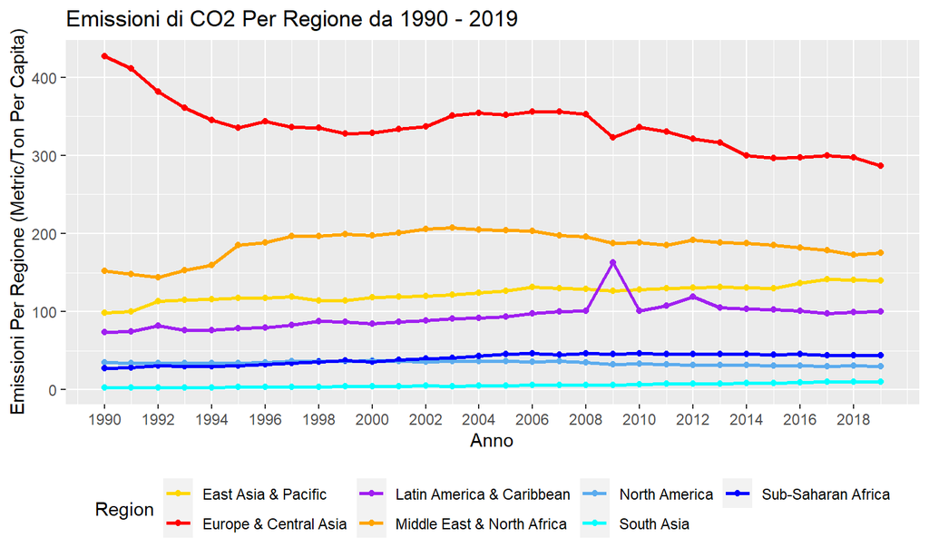

## Anomalia Bahamas

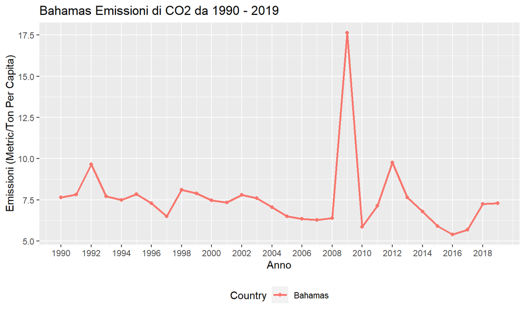

## Analisi grafici da altre fonti

- Grafico da “Data Commons” con dati di “worldbank.org”
- Fonte Grafico: https://datacommons.org/place/country/BHS/
- Fonte Dati: https://datacatalog.worldbank.org/dataset/world-development-indicators/

[figure not shown]

- Grafico da “Our World in Data” con dati di “The Global Carbon Budget dataset”
- Fonte Grafico: https://ourworldindata.org/co2/country/bahamas
- Fonte Dati: https://globalcarbonbudget.org/archive/

[interactive chart not shown]

## Media Delle Emissioni Di CO2

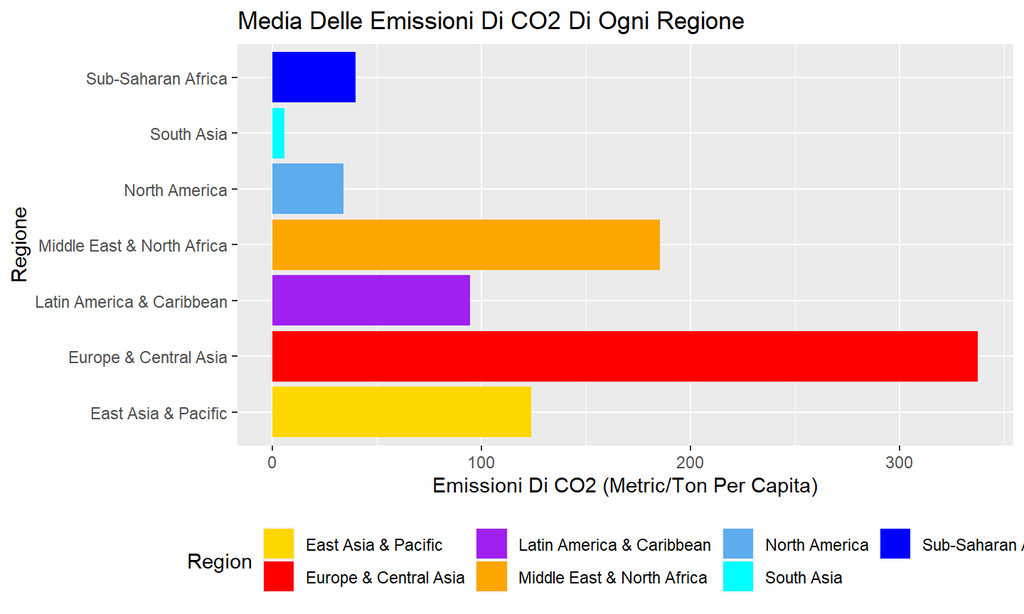

## Media Delle Emissioni Di CO2 Nel Tempo

[video not shown]

## Media Delle Emissioni Di CO2 Di Ogni Paese

[interactive chart not shown]

## Top 10 Paesi Con Più Emissioni Di CO2 in Europa

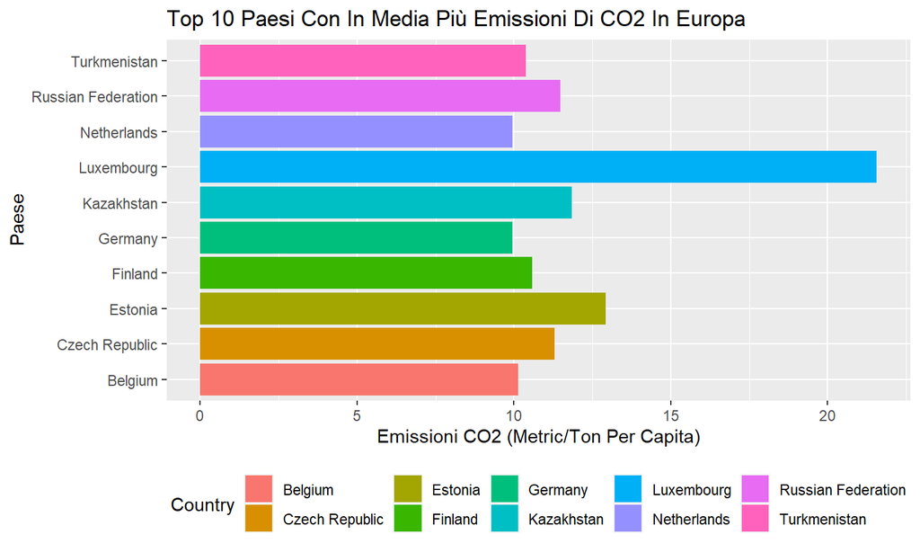

## Domande finali e dataset utilizzati

- Avendo preso in analisi le emissioni del Lussemburgo, quanto è alta la disparità tra la popolazione del Lussemburgo e gli altri paesi in Europa?

**Dataset:**

- Per Popolazione: https://www.kaggle.com/datasets/iamsouravbanerjee/world-population-dataset
- In questo dataset sono indicate le rilevazioni del numero di popolazione dei paesi di tutto il mondo dal 2000 al 2022, ogni rilevazione è stata presa ogni 5 anni.

## Rapporto Tra Quantità Di Popolazione Ed Emissioni Di CO2

## Popolazione Dei 10 Paesi Con Più Emissioni Di CO2 in Europa

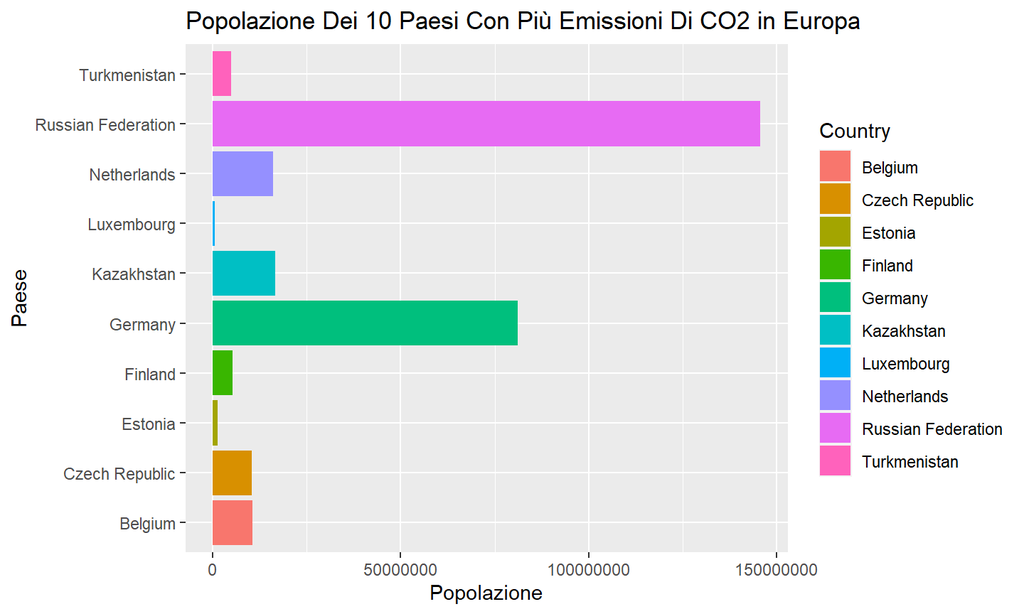